# Types of Recursion

- Tail Recursion
- Head Recursion
- Tree Recursion
- Indirect Recursion
- Nested Recursion

## Tail Recursion

Seen before: Where the function calling itself, is the last statement.

That is means everything (all statements preceding the functon call) is performed at CALLING Time, and function will not beforming at operation as RETURNING time.

```
void fun1(int n){
    if (n > 0){
        cout<<n<<endl;
        fun1(n-1);            //-------------TAIL

    }
}
```

Where we have something where there is something remaining like

```
fun1(n-1)+ x;
```

The above will be performed at RETURNING Time.

But then this WILL not be TAIL recursion.

## Compare Tail Recursion with Loop

The two can be converted to one another.

But lets compare....

## Using Tail Recursion

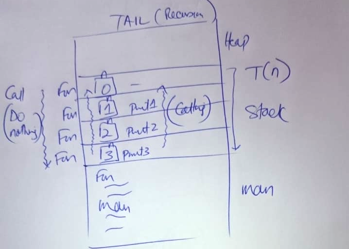

```python
#include <iostream>
#include <climits>
#include <math.h>
using namespace std;
```

```python
void fun(int n){               //---T(n)
    if (n > 0){                //---1
        cout<<n<<endl;         //---1
        fun(n-1);              //---T(n-1)
    }
}
```

```python
int x=3;
fun(x);
```

```
3
2
1
```

## Using While Loop

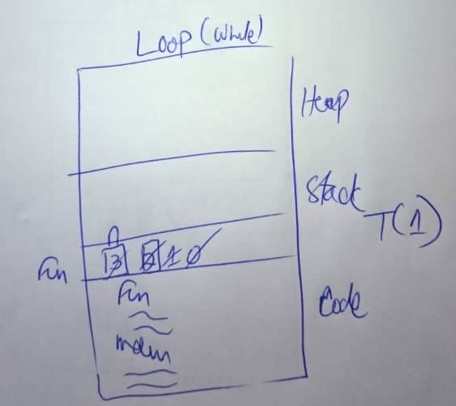

Tail recursion can be easily converted to while loop with vert little effort

In fact,such logic is best suited for while loop

#### Which more efficient? Time:

Both O(n)

#### What is best i.t.o space?

Recursion - **O**(n) Create 4 activation records in stack Calls itself 4 times

Loop - **O**(1) Creates only 1 activation T(1) records in stack Its not calling itself

So Loop is more efficient using Loop

#### Conclusion

If you need to write a tail recursion, it best to convert or to use a loop. Some compiler will see that you using Tail recursion then convert it to a loop.

```python
void funLoop(int n){     //---T(n)
  while (n > 0){         //---1
     cout<<n<<endl;      //---1
     n--;                //---1
  }
}
```

```python
int x_1=3;
funLoop(x_1);
```

```
3
2
1
```